# HFI Report

## Introduction

Here, we look to investigate what factors shape human freedom across the world. The [Human Freedom Index](https://www.kaggle.com/gsutters/the-human-freedom-index) is a way to quantify human freedom based off of measures such as personal, civil, and economic freedom. It uses 76 distinct indicators in the main areas of: Rule of Law, Security and Safety, Movement, Religion, Association, Assembly, and Civil Society, Expression and Information, Identity and Relationships, Size of Government, Legal System and Property Rights, Access to Sound Money, Freedom to Trade Internationally, Regulation of Credit, Labor, and Business. The data operates under the assumption that human freedom is is defined as the absence of coercive constraint and is ranked on a scale from 1 (least freedom) to 10 (most freedom). Through all the protests and controversy, we want to see how these freedom indexes have changed over time, as well as what countries have been progressive enough for these indexes to increase.

The data comes from the Cato Institute, the Fraser Institute, and the Liberales Institut at the Friedrich Naumann Foundation for Freedom.

## Summary

```
## $hf_highest
## [1] "New Zealand"
##
## $hf_lowest
## [1] "Syria"
##
## $hf_highest_region
## [1] "North America"
##
## $wf_highest_region
## [1] "North America"
##
## $ef_highest_region
## [1] "North America"
```

## Table

Since the main focus of our data is to quantify human freedom, the overall trend human freedom scores across the countries, region, the correlation between personal freedom and economic freedom, women-specific Personal Freedom Score and its indicator scores, all of which make up the majority part of the data may be of some interest that enable us to understand more about such quantification of human freedom.

First, we want to examine whether there is a trend of human freedom scores by country over time. (part of the table is displayed due to its length)

| countries | 2017 | 2016 | 2015 | 2014 | 2013 | 2012 | 2011 | 2010 | 2009 | 2008 |
| --- | --- | --- | --- | --- | --- | --- | --- | --- | --- | --- |
| Albania | 7.84 | 7.67 | 7.58 | 7.69 | 7.44 | 7.44 | 7.52 | 7.71 | 7.74 | 7.68 |
| Algeria | 4.99 | 5.22 | 5.04 | 5.20 | 5.16 | 5.06 | 5.15 | 5.26 | 5.28 | 5.29 |
| Angola | 5.40 | 5.89 | 5.79 | 5.44 | 5.28 | 5.35 | 5.37 | 5.44 | 5.44 | 5.02 |
| Argentina | 6.86 | 6.75 | 6.54 | 6.27 | 6.55 | 6.64 | 6.93 | 6.96 | 7.06 | 7.10 |
| Armenia | 7.42 | 7.44 | 7.34 | 7.43 | 7.53 | 7.52 | 7.53 | 7.41 | 7.39 | 7.42 |
| Australia | 8.62 | 8.62 | 8.61 | 8.69 | 8.56 | 8.60 | 8.64 | 8.69 | 8.68 | 8.73 |
| Austria | 8.48 | 8.47 | 8.56 | 8.58 | 8.53 | 8.49 | 8.46 | 8.37 | 8.40 | 8.42 |
| Azerbaijan | 6.22 | 6.07 | 5.97 | 6.12 | 6.11 | 6.07 | 6.07 | 6.36 | 6.29 | 6.44 |
| Bahamas | 7.56 | 7.60 | 7.63 | 7.59 | 7.60 | 7.58 | 7.62 | 7.65 | 7.76 | 7.97 |
| Bahrain | 6.63 | 6.65 | 6.66 | 6.62 | 6.62 | 6.53 | 6.69 | 6.83 | 7.03 | 7.15 |
| Bangladesh | 5.77 | 5.70 | 5.75 | 5.83 | 5.67 | 5.72 | 5.90 | 5.91 | 5.91 | 5.80 |
| Barbados | 7.02 | 7.21 | 7.25 | 7.34 | 7.38 | 7.37 | 7.35 | 7.35 | 7.35 | 7.21 |

From this table, we will be able to tell that the Overall human freedom score across the countries is not showing noticeable improvement from 2008 to 2017, some had slightly improvement while some got worse.

Then looking at specifically in 2017 in more detail, we explore overall human freedom scores across the region

| region | avg_hf_score |
| --- | --- |
| North America | 8.555000 |
| Western Europe | 8.412778 |
| East Asia | 7.911667 |
| Oceania | 7.817500 |
| Eastern Europe | 7.605000 |
| Latin America & the Caribbean | 6.951538 |
| Caucasus & Central Asia | 6.838333 |
| South Asia | 6.467647 |
| Sub-Saharan Africa | 6.231429 |
| Middle East & North Africa | 5.674737 |

In terms of the overall human freedom on average across the region in 2017, North America ranks the highest, followed by Western Europe, East Asia, Oceania, Eastern Europe, Latin America & the Caribbean, Caucasus & Central Asia, South Asia, Sub-Saharan Africa, Middle East & North Africa being the lowest.

After looking at the overall human freedom score, we take a look of the personal and economic scores. Here, by creating a new column, we will be able to tell which aspect of scores outweigh the other in each country. (part of the table is displayed due to its length)

| year | countries | region | pf_score | ef_score | ef_pf_corr |
| --- | --- | --- | --- | --- | --- |
| 2017 | Albania | Eastern Europe | 8.01 | 7.67 | 1.0443286 |
| 2017 | Algeria | Middle East & North Africa | 5.2 | 4.77 | 1.0901468 |
| 2017 | Angola | Sub-Saharan Africa | 5.98 | 4.83 | 1.2380952 |
| 2017 | Argentina | Latin America & the Caribbean | 8.04 | 5.67 | 1.4179894 |
| 2017 | Armenia | Caucasus & Central Asia | 7.15 | 7.7 | 0.9285714 |
| 2017 | Australia | Oceania | 9.16 | 8.07 | 1.1350682 |
| 2017 | Austria | Western Europe | 9.25 | 7.71 | 1.1997406 |
| 2017 | Azerbaijan | Caucasus & Central Asia | 6.1 | 6.34 | 0.9621451 |
| 2017 | Bahamas | Latin America & the Caribbean | 7.87 | 7.25 | 1.0855172 |
| 2017 | Bahrain | Middle East & North Africa | 5.91 | 7.35 | 0.8040816 |
| 2017 | Bangladesh | South Asia | 5.37 | 6.18 | 0.8689320 |
| 2017 | Barbados | Latin America & the Caribbean | 7.59 | 6.45 | 1.1767442 |

Since the data purposely factor out female freedom scores, it can be informative to exmaine. Here, the focus is the most recent year 2017 and to see the difference across region.

| region | total_pf_ss_women |
| --- | --- |
| Sub-Saharan Africa | 277.2 |
| Latin America & the Caribbean | 246.6 |
| Eastern Europe | 209.0 |
| Western Europe | 176.4 |
| South Asia | 129.1 |
| Middle East & North Africa | 102.1 |
| East Asia | 58.8 |
| Caucasus & Central Asia | 55.2 |
| Oceania | 36.3 |
| North America | 20.0 |

Above all, every table of interest present a possible direction to do more exploration on this data.

## Visualizations

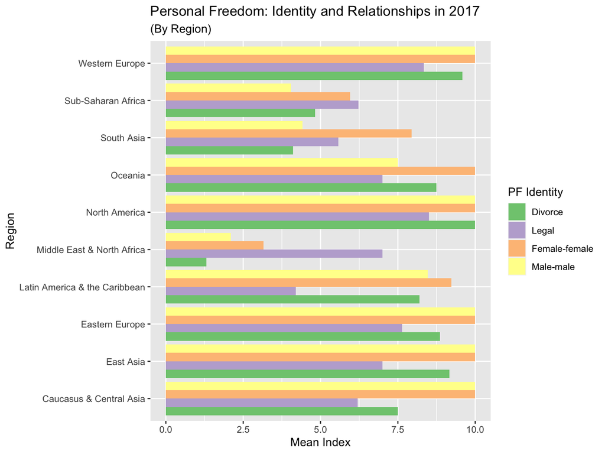

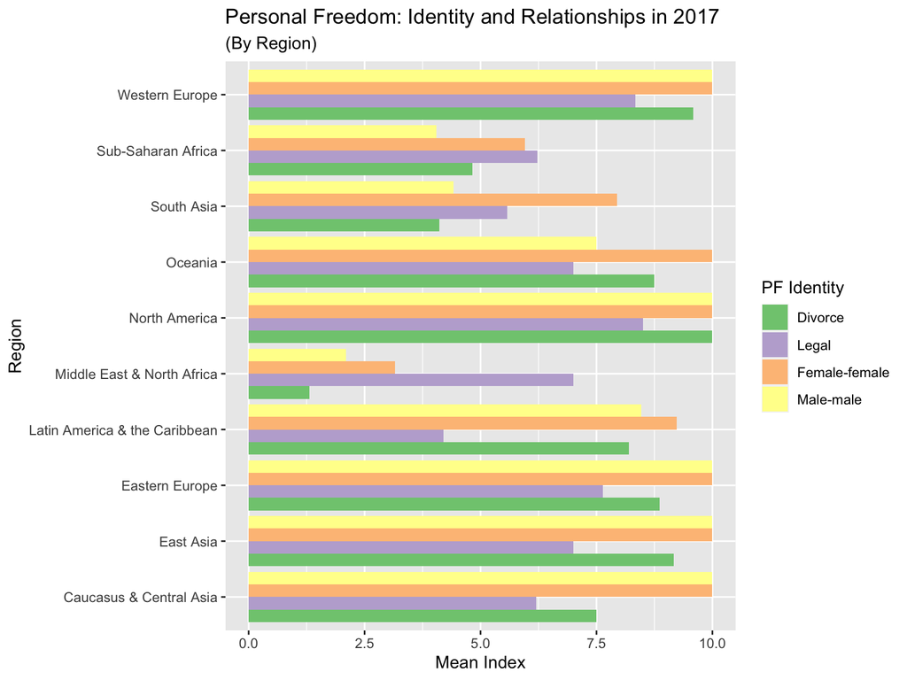

This chart was intended to demonstrate the differences in personal freedoms in establishing one’s own identity, sexual orientation, and to have intimate and familial relationships with others across different regions.

Each of the **PF Identity** labels represents a specific index in personal freedom regarding one’s identity and relationships. The explanations for these labels are as follows:

**Divorce** measures whether women and men **1)** have the same legal rights to initiate divorce and **2)** have the same requirements for divorce.

**Legal** measures the degree to which people are free to legally change their sex and gender.

**Female-female** measures the extent to which sexual relationships between women are legal.

**Male-male** measures the extent to which sexual relationships between men are legal.

From the chart above, we can observe that regions like Sub-Saharan Africa, South Asia, and Middle East & North Africa, which mainly consist of countries that are considered less “developed”, exhibit significantly lower mean index for three or more of the categories considered. Of those areas, the freedom of divorce and the freedom to have male-male relationships have the lowest indexes.

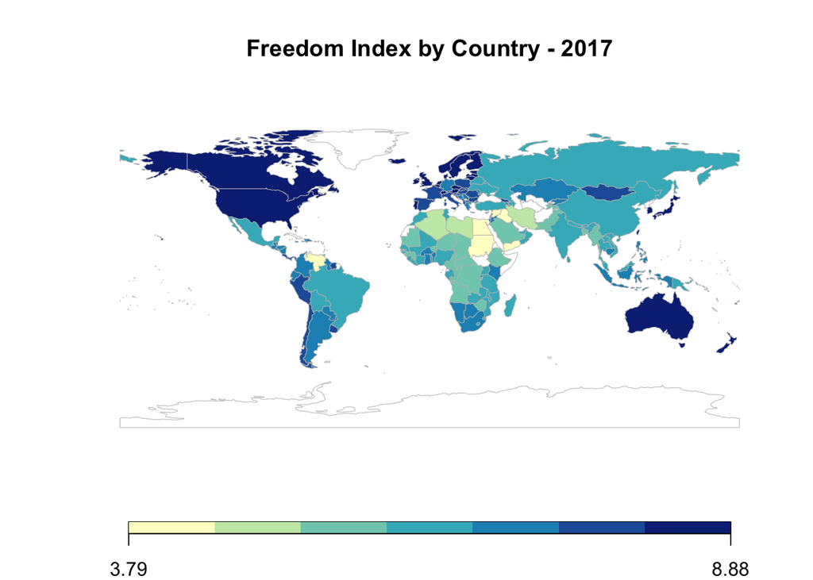

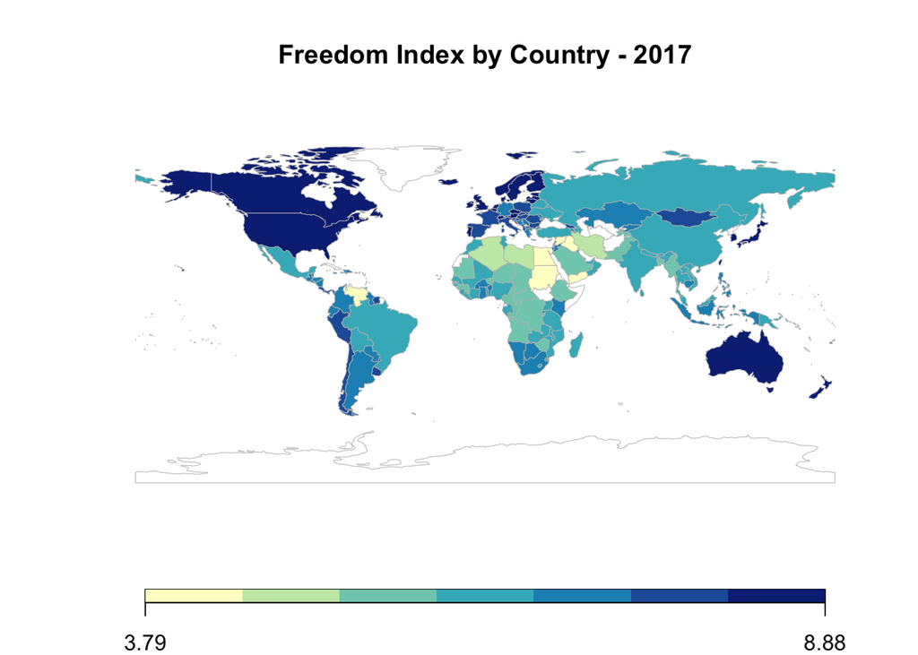

This chart was intended to show a geographical representation of the overall human freedom index values across countries. Yellow indicates low freedom and blue indicates a higher level of freedom. The white represents countries without values. From the graphic, it is clear that countries that are generally considered more “developed” (North America, Australia, and Western Europe) also have a higher level of human freedom.

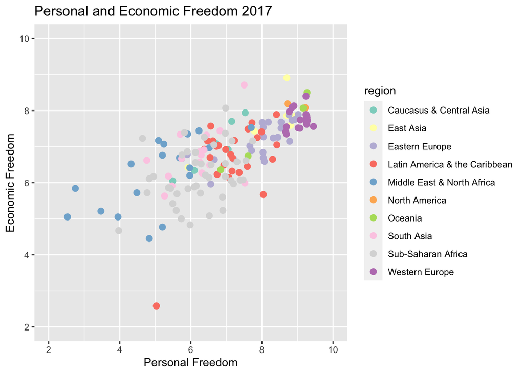

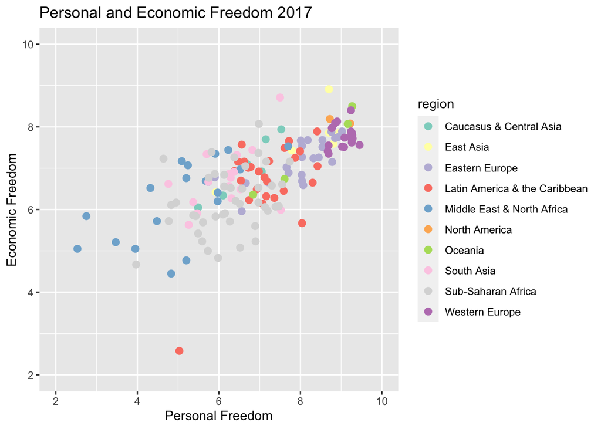